# choosing random effects terms in mixed models

# Example

## setup

```r
library(lme4)
library(Matrix)
library(glmmTMB)
## For rlkj_corr_cholesky; LKJ simulation also available in `rethinking` package
## (GitHub only: remotes::install_github("rmcelreath/rethinking"))
library(nimble)
library(blme)
conflicted::conflict_prefer("simulate", "stats")
```

For this example we’ll think about a forest restoration experiment with four plots; 5 restoration treatments that are applied in each plot (a randomized complete block design); and 6 replicates within each block/treatment.

```r
library(lme4)
set.seed(101)
dd <- expand.grid(plot = factor(1:4),
                  ttt = factor(LETTERS[1:5]),
                  rep = 1:6)
## sample a random 5x5 correlation matrix
cchol <- nimble::rlkj_corr_cholesky(n = 1, eta = 1.2, p = 5) *
    ## scale by random SDs
    rlnorm(5, meanlog = 0, sdlog = 0.2)
theta <- t(cchol)[lower.tri(cchol, diag = TRUE)]
dd$y <- suppressMessages(
    simulate( ~ ttt + (ttt|plot),
             family = gaussian,
             newdata = dd,
             newparams = list(beta = seq(1, by = -0.5, length.out = 5),
                              theta = theta,
                              sigma = 1)))[[1]]
```

## maximal model

We would like to be able to fit `~ ttt + (ttt|plot)`, but that’s very unlikely to actually work:

```r
m1 <- lmer(y ~ ttt + (ttt|plot), data  = dd)
```

```
boundary (singular) fit: see help('isSingular')
```

```r
isSingular(m1)
```

```
[1] TRUE
```

```r
getME(m1, "theta")[getME(m1, "lower") ==0]
```

```
plot.(Intercept)        plot.tttB        plot.tttC        plot.tttD
       0.9465067        1.6882164        0.6333647        0.0000000
       plot.tttE
       0.0000000
```

Seems pretty clear here that the real rank of the estimate is 3 …

## diagnostics

Investigate eigenvectors of the estimated $\Sigma$; we can see again that the covariance matrix has 2 trivial ($\approx 0$) eigenvalues, but not much else; the rotation matrix doesn’t give us any particularly useful clues about how to simplify the model (maybe a heatmap with column (eigenvector) order held fixed and reordering and hierarchical clustering done on the rows would be helpful for identifying clusters? Ideally, the clustering would be done based on shared similarity based on *absolute values* (i.e., we might want to identify linear combinations/contrasts among terms that would allow us to simplify the model … surely someone has done something like this?) [`rePCA()` definitely could use some additions to make it more useful, e.g. a plot method … even the original paper (Bates, Kliegl, et al. 2015) doesn’t offer much guidance …]

```r
(r <- rePCA(m1))
```

```
$plot
Standard deviations (1, .., p=5):
[1] 2.124898e+00 1.259986e+00 1.015020e+00 1.794922e-08 0.000000e+00

Rotation (n x k) = (5 x 5):
           [,1]        [,2]       [,3]       [,4]          [,5]
[1,] -0.2084363 -0.35887528  0.6933225 -0.2152625  5.483875e-01
[2,]  0.8630464  0.30871339  0.2515409  0.1513137  2.714376e-01
[3,]  0.1172202 -0.58554419  0.1806518  0.7293481 -2.807378e-01
[4,]  0.1177251  0.06948193  0.5379321 -0.3810027 -7.394451e-01
[5,]  0.4290752 -0.65438127 -0.3660944 -0.5036412 -1.942890e-16

attr(,"class")
[1] "prcomplist"
```

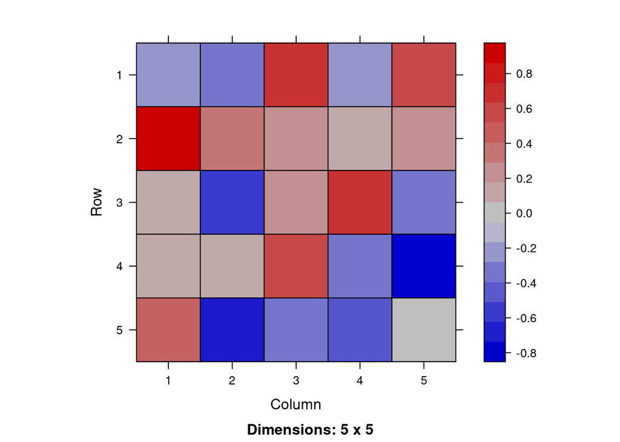

```r
image(Matrix(r$plot$rotation))
```

## constraining the model

```r
m1_homcs_lmer <- lmer(y ~ ttt + (1|plot/ttt), data  = dd)
m1_homcs_glmmTMB <- glmmTMB(y ~ ttt + (1|plot/ttt), data  = dd,
                            REML = TRUE)
m1_hetcs_glmmTMB <- glmmTMB(y ~ ttt + cs(ttt|plot), data  = dd,
                            REML = TRUE)
```

### independence models

```r
m1_diag_glmmTMB <- glmmTMB(y ~ ttt + diag(ttt|plot), data  = dd,
                           REML = TRUE)
## also try afex::mixed?
```

### reduced-rank models

```r
m1_rr1_glmmTMB <- glmmTMB(y ~ ttt + rr(ttt|plot, d=1), data  = dd,
                           REML = TRUE)
m1_diag_rr1_glmmTMB <- glmmTMB(y ~ ttt +
                                   diag(ttt|plot) +
                                   rr(ttt|plot, d=1), data  = dd,
                               REML = TRUE)
m1_diag_rr2_glmmTMB <- glmmTMB(y ~ ttt +
                                   rr(ttt|plot, d=2), data  = dd,
                           REML = TRUE)
```

## parameter constraints/regularization

Constraining just the standard deviations to be positive doesn’t help us: the 5×5 correlation matrix is only rank-4 … a singularity-avoiding prior for the correlation matrix isn’t available yet.

```r
gprior <- data.frame(prior = "gamma(1e8, 2.5)",
                     class = "ranef",
                     coef = "")
m1_us_prior_glmmTMB <- glmmTMB(y ~ ttt +
                                   (ttt|plot),
                               data  = dd,
                               prior = gprior,
                               REML = TRUE)
cormat <- cov2cor(VarCorr(m1_us_prior_glmmTMB)$cond[[1]])
print(eigen(cormat)$value, digits = 3)
```

```
[1] 3.81e+00 8.32e-01 2.62e-01 9.17e-02 4.93e-11
```

### AIC comparison

The more complex models really aren’t doing well in terms of AIC in this case …

```r
all_fits <- ls(pattern = "^m1_")
all_fit_list <- mget(all_fits)
bbmle::AICtab(all_fit_list)
```

```
                    dAIC df
m1_homcs_glmmTMB     0.0 8
m1_homcs_lmer        0.0 8
m1_diag_glmmTMB      1.9 11
m1_hetcs_glmmTMB     3.6 12
m1_diag_rr1_glmmTMB  9.0 16
m1_diag_rr2_glmmTMB 14.0 15
m1_rr1_glmmTMB      29.4 11
m1_us_prior_glmmTMB   NA 21
```

## to do

- provide examples of all (!?) of these approaches. In addition to the simulated example I started with (a single RE with a multi-level factor), might need to include examples with (1) multiple continuous predictors and (2) multiple RE terms in order to illustrate everything …
- fancy ideas; RJMCMC for Bayesian models? Hierarchical clustering to lump/reduce factor levels? Priors on distribution of RR variances (e.g. geometric)?

## references

Barr, Dale J., Roger Levy, Christoph Scheepers, and Harry J. Tily. 2013. “Random Effects Structure for Confirmatory Hypothesis Testing: Keep It Maximal.” *Journal of Memory and Language* 68 (3): 255–78. https://doi.org/10.1016/j.jml.2012.11.001.

Bates, Douglas, Reinhold Kliegl, Shravan Vasishth, and Harald Baayen. 2015. “Parsimonious Mixed Models.” *arXiv:1506.04967 [Stat]*, June. http://arxiv.org/abs/1506.04967.

Bates, Douglas, Martin Mächler, Benjamin M. Bolker, and Steven C. Walker. 2015. “Fitting Linear Mixed-Effects Models Using lme4.” *Journal of Statistical Software* 67 (1): 1–48. https://doi.org/10.18637/jss.v067.i01.

Chung, Yeojin, Sophia Rabe-Hesketh, Vincent Dorie, Andrew Gelman, and Jingchen Liu. 2013. “A Nondegenerate Penalized Likelihood Estimator for Variance Parameters in Multilevel Models.” *Psychometrika*, 1–25. https://doi.org/10.1007/s11336-013-9328-2.

Matuschek, Hannes, Reinhold Kliegl, Shravan Vasishth, Harald Baayen, and Douglas Bates. 2017. “Balancing Type I Error and Power in Linear Mixed Models.” *Journal of Memory and Language* 94: 305–15. https://doi.org/10.1016/j.jml.2017.01.001.

Moritz, Max A., Enric Batllori, and Benjamin M. Bolker. 2023. “The Role of Fire in Terrestrial Vertebrate Richness Patterns.” *Ecology Letters* 26 (4): 563–74. https://doi.org/10.1111/ele.14177.

Singmann, Henrik, and David Kellen. 2019. “An Introduction to Mixed Models for Experimental Psychology.” In *New Methods in Cognitive Psychology*, edited by Daniel Spieler and Eric Schumacher, 1st ed., 4–31. Routledge. https://doi.org/10.4324/9780429318405-2.

Yarkoni, Tal. 2022. “The Generalizability Crisis.” *Behavioral and Brain Sciences* 45 (January): e1. https://doi.org/10.1017/S0140525X20001685.